# Spark Project - Predict Baseball players with a Hall of Fame ballot appearance

## Data Preparation and EDA

```python
%pip install kagglehub
```

## Step 2: Import all essential libaries

```python
from pyspark.sql import SparkSession, functions as F
from pyspark.sql.functions import col, when, lit, coalesce, max as spark_max, first as spark_first, sum as spark_sum
import matplotlib.pyplot as plt
import seaborn as sns
import pandas as pd
import numpy as np
import os
import kagglehub
```

## Step 3: Load dataset and understand the data

```python
# Set dataset path
data_path = kagglehub.dataset_download("seanlahman/the-history-of-baseball")
```

## Initiate Spark session

```python
from pyspark.sql import SparkSession

spark = (
    SparkSession.builder
        .appName("BaseballHallOfFame")
        .master("local[*]")
        .config("spark.driver.host", "127.0.0.1")
        .config("spark.driver.memory", "8g")
        .getOrCreate()
)

print("Spark version:", spark.version)
```

```
Spark version: 3.4.1
```

## Load important tables

```python
# Load core tables for HOF ballot prediction
battingDF = spark.read.option("header", True).option("inferSchema", True) \
    .csv(os.path.join(data_path, "Batting.csv"))

hofDF = spark.read.option("header", True).option("inferSchema", True) \
    .csv(os.path.join(data_path, "hall_of_fame.csv"))

peopleDF = spark.read.option("header", True).option("inferSchema", True) \
    .csv(os.path.join(data_path, "Player.csv"))

salariesDF = spark.read.option("header", True).option("inferSchema", True) \
    .csv(os.path.join(data_path, "Salary.csv"))

pitchingDF = spark.read.option("header", True).option("inferSchema", True) \
    .csv(os.path.join(data_path, "pitching.csv"))

fieldingDF = spark.read.option("header", True).option("inferSchema", True) \
    .csv(os.path.join(data_path, "fielding.csv"))

allStarDF = spark.read.option("header", True).option("inferSchema", True) \
    .csv(os.path.join(data_path, "all_star.csv"))
```

```python
# Cache core tables for performance
battingDF.cache()
hofDF.cache()
peopleDF.cache()
salariesDF.cache()
pitchingDF.cache()
fieldingDF.cache()
allStarDF.cache()
```

```
DataFrame[player_id: string, year: int, game_num: int, game_id: string, team_id: string, league_id: string, gp: double, starting_pos: double]
```

## Explore the dataset

```python
# Explore the data in PySpark
print("Dataset Shapes")

# Shape: (rows, cols)
print("Batting shape:", f"{battingDF.count():,} rows × {len(battingDF.columns)} cols")
print("HOF shape:", f"{hofDF.count():,} rows × {len(hofDF.columns)} cols")
print("People shape:", f"{peopleDF.count():,} rows × {len(peopleDF.columns)} cols")
print("Salaries shape:", f"{salariesDF.count():,} rows × {len(salariesDF.columns)} cols")
print("Pitching shape:", f"{pitchingDF.count():,} rows × {len(pitchingDF.columns)} cols")
print("Fielding shape:", f"{fieldingDF.count():,} rows × {len(fieldingDF.columns)} cols")
print("All-Star shape:", f"{allStarDF.count():,} rows × {len(allStarDF.columns)} cols")


print("\nDataset Columns")

# Columns list
print("Batting columns:", battingDF.columns)
print("HOF columns:", hofDF.columns)
print("People columns:", peopleDF.columns)
print("People columns:", salariesDF.columns)
print("Pitching columns:", pitchingDF.columns)
print("Fielding columns:", fieldingDF.columns)
print("All-Star columns:", allStarDF.columns)

print("Batting preview:")
battingDF.show(5)
print("\nHOF preview:")
hofDF.show(5)
```

```
Dataset Shapes
Batting shape: 101,332 rows × 22 cols
HOF shape: 4,120 rows × 9 cols
People shape: 18,846 rows × 24 cols
Salaries shape: 25,575 rows × 5 cols
Pitching shape: 44,139 rows × 30 cols
Fielding shape: 170,526 rows × 18 cols
All-Star shape: 5,069 rows × 8 cols

Dataset Columns
Batting columns: ['player_id', 'year', 'stint', 'team_id', 'league_id', 'g', 'ab', 'r', 'h', 'double', 'triple', 'hr', 'rbi', 'sb', 'cs', 'bb', 'so', 'ibb', 'hbp', 'sh', 'sf', 'g_idp']
HOF columns: ['player_id', 'yearid', 'votedby', 'ballots', 'needed', 'votes', 'inducted', 'category', 'needed_note']
People columns: ['player_id', 'birth_year', 'birth_month', 'birth_day', 'birth_country', 'birth_state', 'birth_city', 'death_year', 'death_month', 'death_day', 'death_country', 'death_state', 'death_city', 'name_first', 'name_last', 'name_given', 'weight', 'height', 'bats', 'throws', 'debut', 'final…
People columns: ['year', 'team_id', 'league_id', 'player_id', 'salary']
Pitching columns: ['player_id', 'year', 'stint', 'team_id', 'league_id', 'w', 'l', 'g', 'gs', 'cg', 'sho', 'sv', 'ipouts', 'h', 'er', 'hr', 'bb', 'so', 'baopp', 'era', 'ibb', 'wp', 'hbp', 'bk', 'bfp', 'gf', 'r', 'sh', 'sf', 'g_idp']
Fielding columns: ['player_id', 'year', 'stint', 'team_id', 'league_id', 'pos', 'g', 'gs', 'inn_outs', 'po', 'a', 'e', 'dp', 'pb', 'wp', 'sb', 'cs', 'zr']
All-Star columns: ['player_id', 'year', 'game_num', 'game_id', 'team_id', 'league_id', 'gp', 'starting_pos']
Batting preview:
+---------+----+-----+-------+---------+---+-----+----+----+------+------+---+----+---+---+---+---+----+----+----+----+-----+
|player_id|year|stint|team_id|league_id|  g|   ab|   r|   h|double|triple| hr| rbi| sb| cs| bb| so| ibb| hbp|  sh|  sf|g_idp|
+---------+----+-----+-------+---------+---+-----+----+----+------+------+---+----+---+---+---+---+----+----+----+----+-----+
|abercda01|1871|    1|    TRO|     null|  1|  4.0| 0.0| 0.0|   0.0|   0.0|0.0| 0.0|0.0|0.0|0.0|0.0|null|null|null|null| null|
| addybo01|1871|    1|    RC1|     null| 25|118.0|30.0|32.0|   6.0|   0.0|0.0|13.0|8.0|1.0|4.0|0.0|null|null|null|null| null|
|allisar01|1871|    1|    CL1|     null| 29|137.0|28.0|40.0|   4.0|   5.0|0.0|19.0|3.0|1.0|2.0|5.0|null|null|null|null| null|
|allisdo01|1871|    1|    WS3|     null| 27|133.0|28.0|44.0|  10.0|   2.0|2.0|27.0|1.0|1.0|0.0|2.0|null|null|null|null| null|
|ansonca01|1871|    1|    RC1|     null| 25|120.0|29.0|39.0|  11.0|   3.0|0.0|16.0|6.0|2.0|2.0|1.0|null|null|null|null| null|
+---------+----+-----+-------+---------+---+-----+----+----+------+------+---+----+---+---+---+---+----+----+----+----+-----+
only showing top 5 rows


HOF preview:
+---------+------+-------+-------+------+-----+--------+--------+-----------+
|player_id|yearid|votedby|ballots|needed|votes|inducted|category|needed_note|
+---------+------+-------+-------+------+-----+--------+--------+-----------+
| cobbty01|  1936|  BBWAA|  226.0| 170.0|222.0|       Y|  Player|       null|
| ruthba01|  1936|  BBWAA|  226.0| 170.0|215.0|       Y|  Player|       null|
|wagneho01|  1936|  BBWAA|  226.0| 170.0|215.0|       Y|  Player|       null|
|mathech01|  1936|  BBWAA|  226.0| 170.0|205.0|       Y|  Player|       null|
|johnswa01|  1936|  BBWAA|  226.0| 170.0|189.0|       Y|  Player|       null|
+---------+------+-------+-------+------+-----+--------+--------+-----------+
only showing top 5 rows
```

## Join the tables

```python
# Join tables with all columns
print("\nJoin the dataframe with all columns...")
performanceDF = battingDF.alias("bat") \
    .join(pitchingDF.alias("pit"), ["player_id", "year"], "left") \
    .join(fieldingDF.alias("fld"), ["player_id", "year"], "left") \
    .join(salariesDF.alias("sal"), ["player_id", "year"], "left") \
    .join(allStarDF.alias("all"), ["player_id", "year"], "left") \
    .cache()

print(f"Joined: {performanceDF.count():,} records × {len(performanceDF.columns)} cols")
performanceDF.show(5, truncate=False)
print("All columns:", performanceDF.columns)
```

```
Join the dataframe with all columns...
Joined: 214,157 records × 75 cols
+---------+----+-----+-------+---------+---+-----+----+-----+------+------+----+----+---+---+----+----+----+---+---+---+-----+-----+-------+---------+----+----+----+----+----+----+----+------+----+----+----+----+----+-----+----+----+----+----+----+----+----+----+----+----+-----+-----+-------+-------…
|player_id|year|stint|team_id|league_id|g  |ab   |r   |h    |double|triple|hr  |rbi |sb |cs |bb  |so  |ibb |hbp|sh |sf |g_idp|stint|team_id|league_id|w   |l   |g   |gs  |cg  |sho |sv  |ipouts|h   |er  |hr  |bb  |so  |baopp|era |ibb |wp  |hbp |bk  |bfp |gf  |r   |sh  |sf  |g_idp|stint|team_id|league_…
+---------+----+-----+-------+---------+---+-----+----+-----+------+------+----+----+---+---+----+----+----+---+---+---+-----+-----+-------+---------+----+----+----+----+----+----+----+------+----+----+----+----+----+-----+----+----+----+----+----+----+----+----+----+----+-----+-----+-------+-------…
|aaronha01|1973|1    |ATL    |NL       |120|392.0|84.0|118.0|12.0  |1.0   |40.0|96.0|1.0|1.0|68.0|51.0|13.0|1.0|0.0|4.0|7.0  |null |null   |null     |null|null|null|null|null|null|null|null  |null|null|null|null|null|null |null|null|null|null|null|null|null|null|null|null|null |1    |ATL    |NL     …
|aaronha01|1973|1    |ATL    |NL       |120|392.0|84.0|118.0|12.0  |1.0   |40.0|96.0|1.0|1.0|68.0|51.0|13.0|1.0|0.0|4.0|7.0  |null |null   |null     |null|null|null|null|null|null|null|null  |null|null|null|null|null|null |null|null|null|null|null|null|null|null|null|null|null |1    |ATL    |NL     …
|aaronha01|1973|1    |ATL    |NL       |120|392.0|84.0|118.0|12.0  |1.0   |40.0|96.0|1.0|1.0|68.0|51.0|13.0|1.0|0.0|4.0|7.0  |null |null   |null     |null|null|null|null|null|null|null|null  |null|null|null|null|null|null |null|null|null|null|null|null|null|null|null|null|null |1    |ATL    |NL     …
|aaronto01|1962|1    |ML1    |NL       |141|334.0|54.0|77.0 |20.0  |2.0   |8.0 |38.0|6.0|0.0|41.0|58.0|0.0 |0.0|4.0|3.0|10.0 |null |null   |null     |null|null|null|null|null|null|null|null  |null|null|null|null|null|null |null|null|null|null|null|null|null|null|null|null|null |1    |ML1    |NL     …
|aaronto01|1962|1    |ML1    |NL       |141|334.0|54.0|77.0 |20.0  |2.0   |8.0 |38.0|6.0|0.0|41.0|58.0|0.0 |0.0|4.0|3.0|10.0 |null |null   |null     |null|null|null|null|null|null|null|null  |null|null|null|null|null|null |null|null|null|null|null|null|null|null|null|null|null |1    |ML1    |NL     …
+---------+----+-----+-------+---------+---+-----+----+-----+------+------+----+----+---+---+----+----+----+---+---+---+-----+-----+-------+---------+----+----+----+----+----+----+----+------+----+----+----+----+----+-----+----+----+----+----+----+----+----+----+----+----+-----+-----+-------+-------…
only showing top 5 rows

All columns: ['player_id', 'year', 'stint', 'team_id', 'league_id', 'g', 'ab', 'r', 'h', 'double', 'triple', 'hr', 'rbi', 'sb', 'cs', 'bb', 'so', 'ibb', 'hbp', 'sh', 'sf', 'g_idp', 'stint', 'team_id', 'league_id', 'w', 'l', 'g', 'gs', 'cg', 'sho', 'sv', 'ipouts', 'h', 'er', 'hr', 'bb', 'so', 'baopp'…
```

## Select relevant columns

```python
print("Selecting relevant columns from performanceDF...")

# Important columns for HoF prediction
important_cols = [
    # IDs
    "bat.player_id", "bat.year",

    # Batting stats
    "bat.g", "bat.ab", "bat.h", "bat.hr", "bat.rbi", "bat.bb", "bat.so",

    # Pitching stats
    "pit.w", "pit.l", "pit.era", "pit.ipouts", "pit.so as pit_so",

    # Fielding stats
    "fld.pos", "fld.po", "fld.a", "fld.e",

    # Salary - Re-added for model performance
    "sal.salary",

    # All-Star
    "all.game_num"

    # Save to join with HoF label later on
]

# Select important columns only
hof_ready = performanceDF.selectExpr(*important_cols).cache()

print(f"Reduced: {hof_ready.count():,} records × {len(hof_ready.columns)} cols")
print("Columns:", hof_ready.columns)
hof_ready.show(5, truncate=False)
```

```
Selecting relevant columns from performanceDF...
Reduced: 214,157 records × 20 cols
Columns: ['player_id', 'year', 'g', 'ab', 'h', 'hr', 'rbi', 'bb', 'so', 'w', 'l', 'era', 'ipouts', 'pit_so', 'pos', 'po', 'a', 'e', 'salary', 'game_num']
+---------+----+---+-----+-----+----+----+----+----+----+----+----+------+------+---+-----+----+---+------+--------+
|player_id|year|g  |ab   |h    |hr  |rbi |bb  |so  |w   |l   |era |ipouts|pit_so|pos|po   |a   |e  |salary|game_num|
+---------+----+---+-----+-----+----+----+----+----+----+----+----+------+------+---+-----+----+---+------+--------+
|aaronha01|1973|120|392.0|118.0|40.0|96.0|68.0|51.0|null|null|null|null  |null  |LF |171.0|3.0 |4.0|null  |0       |
|aaronha01|1973|120|392.0|118.0|40.0|96.0|68.0|51.0|null|null|null|null  |null  |OF |206.0|5.0 |5.0|null  |0       |
|aaronha01|1973|120|392.0|118.0|40.0|96.0|68.0|51.0|null|null|null|null  |null  |RF |36.0 |2.0 |1.0|null  |0       |
|aaronto01|1962|141|334.0|77.0 |8.0 |38.0|41.0|58.0|null|null|null|null  |null  |1B |507.0|45.0|6.0|null  |null    |
|aaronto01|1962|141|334.0|77.0 |8.0 |38.0|41.0|58.0|null|null|null|null  |null  |2B |0.0  |1.0 |0.0|null  |null    |
+---------+----+---+-----+-----+----+----+----+----+----+----+----+------+------+---+-----+----+---+------+--------+
only showing top 5 rows
```

The relevant columns were selected. Part of this are batting and pitching, as well as fielding stats, as well as the players salary (a good indicator for a highly valued player) and the allstar games (HoF worthy players often play there)

## Select the feature

```python
# Create ballot appearance column, which states if a players was nominated for the HoF
hofDF_with_ballot = hofDF.withColumn("ballot_appearance", lit(1))

hof_labels = hofDF_with_ballot.groupBy("player_id") \
    .agg(
        spark_max("yearid").alias("latest_year"),
        spark_first("ballot_appearance").alias("ballot_appearance")
    ) \
    .cache()

# Join on the feature DF
labeledDF = hof_ready.join(hof_labels,
                          hof_ready.player_id == hof_labels.player_id, "left") \
    .drop(hof_labels.player_id) \
    .na.fill({"ballot_appearance": 0}) \
    .cache()

labeledDF = labeledDF.withColumn(
    "all_star_games",
    when(col("game_num").isNotNull(), 1).otherwise(0)
)
labeledDF.show(5)
```

```
+---------+----+---+-----+-----+----+----+----+----+----+----+----+------+------+---+-----+----+---+------+--------+-----------+-----------------+--------------+
|player_id|year|  g|   ab|    h|  hr| rbi|  bb|  so|   w|   l| era|ipouts|pit_so|pos|   po|   a|  e|salary|game_num|latest_year|ballot_appearance|all_star_games|
+---------+----+---+-----+-----+----+----+----+----+----+----+----+------+------+---+-----+----+---+------+--------+-----------+-----------------+--------------+
|aaronha01|1973|120|392.0|118.0|40.0|96.0|68.0|51.0|null|null|null|  null|  null| LF|171.0| 3.0|4.0|  null|       0|       1982|                1|             1|
|aaronha01|1973|120|392.0|118.0|40.0|96.0|68.0|51.0|null|null|null|  null|  null| OF|206.0| 5.0|5.0|  null|       0|       1982|                1|             1|
|aaronha01|1973|120|392.0|118.0|40.0|96.0|68.0|51.0|null|null|null|  null|  null| RF| 36.0| 2.0|1.0|  null|       0|       1982|                1|             1|
|aaronto01|1962|141|334.0| 77.0| 8.0|38.0|41.0|58.0|null|null|null|  null|  null| 1B|507.0|45.0|6.0|  null|    null|       null|                0|             0|
|aaronto01|1962|141|334.0| 77.0| 8.0|38.0|41.0|58.0|null|null|null|  null|  null| 2B|  0.0| 1.0|0.0|  null|    null|       null|                0|             0|
+---------+----+---+-----+-----+----+----+----+----+----+----+----+------+------+---+-----+----+---+------+--------+-----------+-----------------+--------------+
only showing top 5 rows
```

```python
from pyspark.sql.window import Window
from pyspark.sql import functions as F
from pyspark.sql.functions import (
    col,
    when,
    first,
    avg,
    sum as spark_sum
)

# Transform the data from player-position-per-year to player-per-year
# This is done by aggregating some stats, taking any for others and an average for some others
# The position with the most put-outs (po) is taken (as games is just the same everywhere)

# Step 1: Define how we rank a player's various roles in a single season
window_po = Window.partitionBy("player_id", "year").orderBy(col("po").desc())
window_first = Window.partitionBy("player_id", "year").orderBy(col("player_id"))  # Stable order

# Step 2: Assign a rank to each row so the primary position can be separated from secondary ones
df_with_rank = (
    labeledDF
        .withColumn("rn_po", F.row_number().over(window_po))
        .withColumn("rn_first", F.row_number().over(window_first))
)

# Step 3: Flatten everything so we have exactly one row per player, per year
player_year_stats = df_with_rank.groupBy("player_id", "year").agg(
    # First values (identical across positions)
    first("g").alias("g"),
    first("ab").alias("ab"),
    first("h").alias("h"),
    first("hr").alias("hr"),
    first("rbi").alias("rbi"),
    first("bb").alias("bb"),
    first("so").alias("so"),
    first("latest_year").alias("latest_year"),
    first("ballot_appearance").alias("ballot_appearance"),
    first("all_star_games").alias("all_star_games"),
    first("salary").alias("salary"),

    # Sum across positions
    spark_sum("w").alias("w"),
    spark_sum("l").alias("l"),
    avg("era").alias("era"),
    spark_sum("ipouts").alias("ipouts"),
    spark_sum("pit_so").alias("pit_so"),
    spark_sum("po").alias("po"),
    spark_sum("a").alias("a"),
    spark_sum("e").alias("e"),

    # Primary position (highest po row)
    first(when(col("rn_po") == 1, col("pos"))).alias("pos")
).cache()

print(f"Player-year rows: {player_year_stats.count():,} rows")
player_year_stats.filter(col("player_id") == "aaronha01").show()

labeledDF = player_year_stats
```

```
Player-year rows: 93,898 rows
+---------+----+---+-----+-----+----+-----+----+----+-----------+-----------------+--------------+------+----+----+----+------+------+------+----+----+---+
|player_id|year|  g|   ab|    h|  hr|  rbi|  bb|  so|latest_year|ballot_appearance|all_star_games|salary|   w|   l| era|ipouts|pit_so|    po|   a|   e|pos|
+---------+----+---+-----+-----+----+-----+----+----+-----------+-----------------+--------------+------+----+----+----+------+------+------+----+----+---+
|aaronha01|1973|120|392.0|118.0|40.0| 96.0|68.0|51.0|       1982|                1|             1|  null|null|null|null|  null|  null| 413.0|10.0|10.0| OF|
|aaronha01|1960|153|590.0|172.0|40.0|126.0|60.0|63.0|       1982|                1|             1|  null|null|null|null|  null|  null|1290.0|52.0|22.0| OF|
|aaronha01|1963|161|631.0|201.0|44.0|130.0|78.0|94.0|       1982|                1|             1|  null|null|null|null|  null|  null| 534.0|22.0|11.0| OF|
|aaronha01|1968|160|606.0|174.0|29.0| 86.0|64.0|62.0|       1982|                1|             1|  null|null|null|null|  null|  null| 747.0|34.0| 8.0| OF|
|aaronha01|1961|155|603.0|197.0|34.0|120.0|56.0|64.0|       1982|                1|             1|  null|null|null|null|  null|  null|1514.0|56.0|28.0| OF|
|aaronha01|1975|137|465.0|109.0|12.0| 60.0|70.0|51.0|       1982|                1|             1|  null|null|null|null|  null|  null|   4.0| 0.0| 0.0| LF|
|aaronha01|1965|150|570.0|181.0|32.0| 89.0|60.0|81.0|       1982|                1|             1|  null|null|null|null|  null|  null| 595.0|21.0| 8.0| OF|
|aaronha01|1956|153|609.0|200.0|26.0| 92.0|37.0|54.0|       1982|                1|             1|  null|null|null|null|  null|  null| 629.0|34.0|26.0| OF|
|aaronha01|1970|150|516.0|154.0|38.0|118.0|74.0|63.0|       1982|                1|             1|  null|null|null|null|  null|  null| 543.0|20.0|13.0| OF|
|aaronha01|1959|154|629.0|223.0|39.0|123.0|51.0|54.0|       1982|                1|             1|  null|null|null|null|  null|  null|1060.0|68.0|20.0| OF|
|aaronha01|1966|158|603.0|168.0|44.0|127.0|76.0|96.0|       1982|                1|             1|  null|null|null|null|  null|  null| 632.0|24.0| 8.0| OF|
|aaronha01|1971|139|495.0|162.0|47.0|118.0|71.0|58.0|       1982|                1|             1|  null|null|null|null|  null|  null| 838.0|42.0| 7.0| 1B|
|aaronha01|1962|156|592.0|191.0|45.0|128.0|66.0|73.0|       1982|                1|             1|  null|null|null|null|  null|  null|1360.0|44.0|28.0| OF|
|aaronha01|1972|129|449.0|119.0|34.0| 77.0|92.0|55.0|       1982|                1|             1|  null|null|null|null|  null|  null|1024.0|74.0|20.0| 1B|
|aaronha01|1958|153|601.0|196.0|30.0| 95.0|59.0|49.0|       1982|                1|             1|  null|null|null|null|  null|  null| 611.0|24.0|10.0| OF|
|aaronha01|1967|155|600.0|184.0|39.0|109.0|63.0|97.0|       1982|                1|             1|  null|null|null|null|  null|  null| 642.0|24.0|14.0| OF|
|aaronha01|1976| 85|271.0| 62.0|10.0| 35.0|35.0|38.0|       1982|                1|             0|  null|null|null|null|  null|  null|   2.0| 0.0| 0.0| LF|
|aaronha01|1964|145|570.0|187.0|24.0| 95.0|62.0|46.0|       1982|                1|             1|  null|null|null|null|  null|  null| 547.0|42.0|11.0| OF|
|aaronha01|1957|151|615.0|198.0|44.0|132.0|57.0|58.0|       1982|                1|             1|  null|null|null|null|  null|  null| 689.0|18.0|12.0| OF|
|aaronha01|1954|122|468.0|131.0|13.0| 69.0|28.0|39.0|       1982|                1|             0|  null|null|null|null|  null|  null| 440.0|10.0|14.0| OF|
+---------+----+---+-----+-----+----+-----+----+----+-----------+-----------------+--------------+------+----+----+----+------+------+------+----+----+---+
only showing top 20 rows
```

## Aggregate player career stats

```python
# Aggregation by player career stats for all years
player_stats = (
    labeledDF
    .groupBy("player_id", "ballot_appearance")  # one row per player
    .agg(
        # Batting totals over career
        spark_sum("g").alias("g"),
        spark_sum("ab").alias("ab"),
        spark_sum("h").alias("h"),
        spark_sum("hr").alias("hr"),
        spark_sum("rbi").alias("rbi"),
        spark_sum("bb").alias("bb"),
        spark_sum("so").alias("so"),

        # Pitching totals over career
        spark_sum("w").alias("w"),
        spark_sum("l").alias("l"),
        avg("era").alias("era"),
        spark_sum("ipouts").alias("ipouts"),
        spark_sum("pit_so").alias("pit_so"),

        # Fielding totals over career
        spark_sum("po").alias("po"),
        spark_sum("a").alias("a"),
        spark_sum("e").alias("e"),

        # Total career earnings is usually the strongest predictor
        spark_sum("salary").alias("salary"),

        # Primary position: first position observed
        first("pos").alias("pos"),

        # Total All-Star Games played
        spark_sum("all_star_games").alias("all_star_games")
    )
    .cache()
)

player_stats.show(5, truncate=False)
print(f"Player-level stats: {player_stats.count():,} rows")
```

```
+---------+-----------------+---+-----+-----+---+----+----+----+----+----+----+------+------+-----+----+----+------+---+--------------+
|player_id|ballot_appearance|g  |ab   |h    |hr |rbi |bb  |so  |w   |l   |era |ipouts|pit_so|po   |a   |e   |salary|pos|all_star_games|
+---------+-----------------+---+-----+-----+---+----+----+----+----+----+----+------+------+-----+----+----+------+---+--------------+
|bakerda01|0                |9  |20.0 |5.0  |0.0|2.0 |3.0 |3.0 |null|null|null|null  |null  |5.0  |16.0|5.0 |null  |3B |0             |
|blakeli01|0                |34 |102.0|23.0 |0.0|10.0|5.0 |14.0|null|null|null|null  |null  |72.0 |4.0 |1.0 |null  |OF |0             |
|blatnjo01|0                |131|427.0|110.0|6.0|45.0|37.0|81.0|null|null|null|null  |null  |239.0|11.0|15.0|null  |OF |0             |
|brady01  |0                |1  |4.0  |1.0  |0.0|0.0 |0.0 |0.0 |null|null|null|null  |null  |4.0  |1.0 |3.0 |null  |OF |0             |
|brennji02|0                |3  |0.0  |0.0  |0.0|0.0 |0.0 |0.0 |0   |0   |18.0|6.0   |2     |0.0  |0.0 |0.0 |null  |P  |0             |
+---------+-----------------+---+-----+-----+---+----+----+----+----+----+----+------+------+-----+----+----+------+---+--------------+
only showing top 5 rows

Player-level stats: 18,659 rows
```

## Show class distribution

```
Class distribution of ballot_appearance in labeledDF:

Class counts:
No Ballot (class 0): 17,485
Ballot Appearance (class 1): 1,174
```

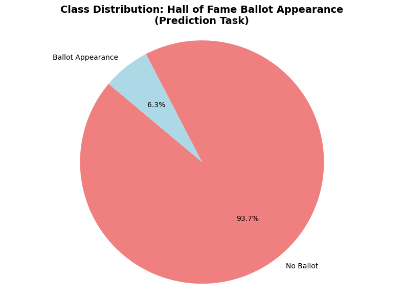

```python
from pyspark.sql.functions import count

print("Class distribution of ballot_appearance in labeledDF:")

# Show counts of players with a ballot appearance in the HoF and the ones without
class_counts = player_stats.groupBy("ballot_appearance") \
    .agg(count("*").alias("count")) \
    .orderBy("ballot_appearance") \
    .collect()

print("\nClass counts:")
for row in class_counts:
    label = "Ballot Appearance" if row["ballot_appearance"] == 1 else "No Ballot"
    print(f"{label} (class {row['ballot_appearance']}): {row['count']:,}")

# Extract for pie chart
labels = ["No Ballot", "Ballot Appearance"]
sizes = [row["count"] for row in class_counts]

# Create pie chart
plt.figure(figsize=(8, 6))
plt.pie(sizes, labels=labels, autopct='%1.1f%%', startangle=140, colors=['lightcoral', 'lightblue'])
plt.title("Class Distribution: Hall of Fame Ballot Appearance\n(Prediction Task)", fontsize=14, fontweight='bold')
plt.axis('equal')
plt.tight_layout()
plt.show()
```

# Preprocessing before ETA

## Check for duplicates

```python
#Show exact duplicate rows
player_stats.groupBy("player_id").agg(count("*").alias("dup_count")).filter(col("dup_count") > 1).show()
```

```
+---------+---------+
|player_id|dup_count|
+---------+---------+
+---------+---------+
```

## Replace missing values

```python
# Count nan string values per column
nan_count = player_stats.select([
    spark_sum(when(col(c).isNull(), 1).otherwise(0)).alias(c)
    for c in player_stats.columns
])

print("\nCount of NULL values per column:")
nan_count.show(1, truncate=False)
```

```
Count of NULL values per column:
+---------+-----------------+---+---+---+---+---+---+----+----+----+----+------+------+---+---+---+------+---+--------------+
|player_id|ballot_appearance|g  |ab |h  |hr |rbi|bb |so  |w   |l   |era |ipouts|pit_so|po |a  |e  |salary|pos|all_star_games|
+---------+-----------------+---+---+---+---+---+---+----+----+----+----+------+------+---+---+---+------+---+--------------+
|0        |0                |0  |439|439|439|574|439|1975|9533|9533|9561|9533  |9533  |201|202|203|13831 |351|0             |
+---------+-----------------+---+---+---+---+---+---+----+----+----+----+------+------+---+---+---+------+---+--------------+
```

```python
# Replace missing values
player_stats = player_stats.withColumn("w",
    when(col("pos").isin("1", "P"), col("w")).otherwise(lit(0))) \
    .withColumn("l",
    when(col("pos").isin("1", "P"), col("l")).otherwise(lit(0))) \
    .withColumn("era",
    when((col("pos").isin("1", "P")) & (col("ipouts") > 0), col("era")).otherwise(lit(0)))
```

```python
player_stats.show(5, truncate=False)
```

```
+---------+-----------------+---+-----+-----+---+----+----+----+---+---+----+------+------+-----+----+----+------+---+--------------+
|player_id|ballot_appearance|g  |ab   |h    |hr |rbi |bb  |so  |w  |l  |era |ipouts|pit_so|po   |a   |e   |salary|pos|all_star_games|
+---------+-----------------+---+-----+-----+---+----+----+----+---+---+----+------+------+-----+----+----+------+---+--------------+
|bakerda01|0                |9  |20.0 |5.0  |0.0|2.0 |3.0 |3.0 |0  |0  |0.0 |null  |null  |5.0  |16.0|5.0 |null  |3B |0             |
|blakeli01|0                |34 |102.0|23.0 |0.0|10.0|5.0 |14.0|0  |0  |0.0 |null  |null  |72.0 |4.0 |1.0 |null  |OF |0             |
|blatnjo01|0                |131|427.0|110.0|6.0|45.0|37.0|81.0|0  |0  |0.0 |null  |null  |239.0|11.0|15.0|null  |OF |0             |
|brady01  |0                |1  |4.0  |1.0  |0.0|0.0 |0.0 |0.0 |0  |0  |0.0 |null  |null  |4.0  |1.0 |3.0 |null  |OF |0             |
|brennji02|0                |3  |0.0  |0.0  |0.0|0.0 |0.0 |0.0 |0  |0  |18.0|6.0   |2     |0.0  |0.0 |0.0 |null  |P  |0             |
+---------+-----------------+---+-----+-----+---+----+----+----+---+---+----+------+------+-----+----+----+------+---+--------------+
only showing top 5 rows
```

```python
# Fill remaining empty values based on baseball logic:

# Calculate Median Salary for Imputation
median_res = player_stats.filter(col("salary").isNotNull()).approxQuantile("salary", [0.5], 0.01)
median_salary = median_res[0] if len(median_res) > 0 else 0
print(f"Median Salary for imputation: {median_salary:,.2f}")


# Add an indicator so the model knows who actually had salary data
player_stats = player_stats \
    .withColumn("has_salary_info", when(col("salary").isNotNull(), lit(1.0)).otherwise(lit(0.0))) \
    .withColumn("salary", coalesce(col("salary"), lit(median_salary)))

# Pitching stats (ipouts, pit_so) are 0 for not pitchers
player_stats = player_stats \
    .withColumn("ipouts", when(col("pos").isin("1", "P"), col("ipouts")).otherwise(lit(0))) \
    .withColumn("pit_so", when(col("pos").isin("1", "P"), col("pit_so")).otherwise(lit(0)))

# Fielding stats (po, a, e) are 0 when no games played
player_stats = player_stats \
    .withColumn("po", coalesce(col("po"), lit(0))) \
    .withColumn("a", coalesce(col("a"), lit(0))) \
    .withColumn("e", coalesce(col("e"), lit(0)))

# Position is filled with "Unknown"
player_stats = player_stats.withColumn("pos", coalesce(col("pos"), lit("U")))

# All Null Values filled
player_stats.select([count(when(col(c).isNull(), c)).alias(c) for c in player_stats.columns]).show()
```

```
Median Salary for imputation: 1,528,400.00
+---------+-----------------+---+---+---+---+---+---+----+---+---+---+------+------+---+---+---+------+---+--------------+---------------+
|player_id|ballot_appearance|  g| ab|  h| hr|rbi| bb|  so|  w|  l|era|ipouts|pit_so| po|  a|  e|salary|pos|all_star_games|has_salary_info|
+---------+-----------------+---+---+---+---+---+---+----+---+---+---+------+------+---+---+---+------+---+--------------+---------------+
|        0|                0|  0|439|439|439|574|439|1975|  0|  0|  0|     0|     0|  0|  0|  0|     0|  0|             0|              0|
+---------+-----------------+---+---+---+---+---+---+----+---+---+---+------+------+---+---+---+------+---+--------------+---------------+
```

```python
# Fill remaining null values with 0
player_stats = player_stats \
    .withColumn("g", coalesce(col("g"), lit(0))) \
    .withColumn("ab", coalesce(col("ab"), lit(0))) \
    .withColumn("h", coalesce(col("h"), lit(0))) \
    .withColumn("hr", coalesce(col("hr"), lit(0))) \
    .withColumn("rbi", coalesce(col("rbi"), lit(0))) \
    .withColumn("bb", coalesce(col("bb"), lit(0))) \
    .withColumn("so", coalesce(col("so"), lit(0)))

player_stats.select([count(when(col(c).isNull(), c)).alias(c) for c in player_stats.columns]).show()
```

```
+---------+-----------------+---+---+---+---+---+---+---+---+---+---+------+------+---+---+---+------+---+--------------+---------------+
|player_id|ballot_appearance|  g| ab|  h| hr|rbi| bb| so|  w|  l|era|ipouts|pit_so| po|  a|  e|salary|pos|all_star_games|has_salary_info|
+---------+-----------------+---+---+---+---+---+---+---+---+---+---+------+------+---+---+---+------+---+--------------+---------------+
|        0|                0|  0|  0|  0|  0|  0|  0|  0|  0|  0|  0|     0|     0|  0|  0|  0|     0|  0|             0|              0|
+---------+-----------------+---+---+---+---+---+---+---+---+---+---+------+------+---+---+---+------+---+--------------+---------------+
```

## ETA

### Key stats by ballot appearance

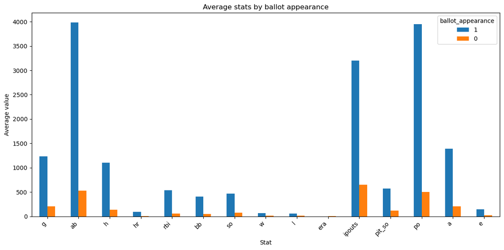

```python
# 1) Average key stats by ballot_appearance

stats_cols = ["g", "ab", "h", "hr", "rbi", "bb", "so", "w", "l", "era", "ipouts", "pit_so", "po", "a", "e"]

avg_stats_sdf = (
    player_stats
    .groupBy("ballot_appearance")
    .agg(*[F.avg(c).alias(c) for c in stats_cols])
)

avg_stats_pdf = avg_stats_sdf.toPandas().set_index("ballot_appearance").T

plt.figure(figsize=(10, 6))
avg_stats_pdf.plot(kind="bar", figsize=(12, 6))
plt.title("Average stats by ballot appearance")
plt.ylabel("Average value")
plt.xlabel("Stat")
plt.xticks(rotation=45, ha="right")
plt.legend(title="ballot_appearance")
plt.tight_layout()
plt.show()
```

It can be seen, that the average values for players with a ballot appearance are throughout the board much higher, than the values of the rest of the players. This makes sense, as these players have usually played for a long time, and performed well over that time in comparison to their peers.

### Count players by position

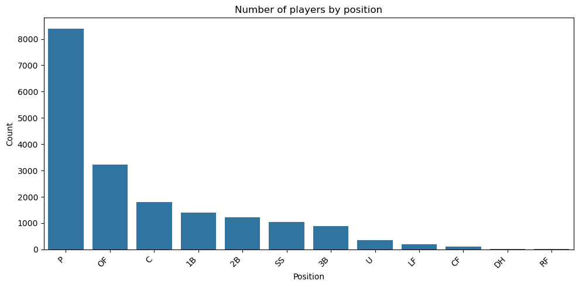

```python
pos_counts_pdf = (
    player_stats
    .groupBy("pos")
    .count()
    .orderBy("count", ascending=False)
    .toPandas()
)

plt.figure(figsize=(10, 5))
sns.barplot(data=pos_counts_pdf, x="pos", y="count")
plt.title("Number of players by position")
plt.xlabel("Position")
plt.ylabel("Count")
plt.xticks(rotation=45, ha="right")
plt.tight_layout()
plt.show()
```

It is visible, that most players are pitchers, and then there come the Out Fielders. In the NBA, a lot of pitchers are needed for each team, to switch them out during a game etc. Out Fielders are the second most often, as most players start their career of in center Field, as it is considered to be an "easier" position, and only if they perform well move into other positions.

### Ballot appearance rate by position

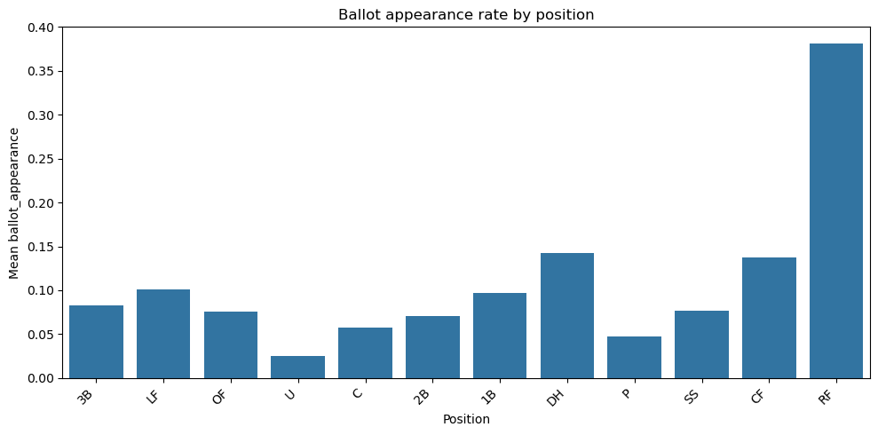

```python
ballot_rate_pos_pdf = (
    player_stats
    .groupBy("pos")
    .agg(F.mean(F.col("ballot_appearance").cast("double")).alias("ballot_rate"))
    .toPandas()
)

plt.figure(figsize=(10, 5))
sns.barplot(data=ballot_rate_pos_pdf, x="pos", y="ballot_rate")
plt.title("Ballot appearance rate by position")
plt.xlabel("Position")
plt.ylabel("Mean ballot_appearance")
plt.xticks(rotation=45, ha="right")
plt.tight_layout()
plt.show()
```

Here, it is clearly visible, that the position Right Fielder has the by far highest rate of their players appearing on ballots. However, as it is also the least played position overall, this may be due to just a few outliers, and not be a statistically relevant correlation. The least players get chosen from the position U for unknown, which makes sense as a prestigious players position would usually be known and kept in the data.

### Correlation with ballot appearance

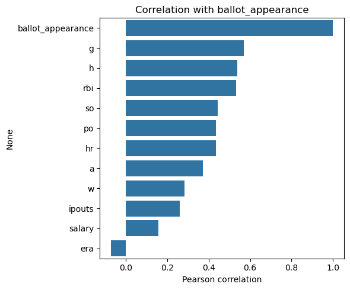

```python
num_cols = ["ballot_appearance", "salary", "g", "h", "hr", "rbi", "so", "w", "era", "ipouts", "salary", "po", "a"]
num_pdf = player_stats.select(num_cols).toPandas()

corr = num_pdf.corr()["ballot_appearance"].sort_values(ascending=False)

plt.figure(figsize=(6, 5))
sns.barplot(x=corr.values, y=corr.index)
plt.title("Correlation with ballot_appearance")
plt.xlabel("Pearson correlation")
plt.tight_layout()
plt.show()
```

This graph shows, that the indicators highly correlated with a ballot appearance are the amount of games played, as well as hits and rbi. Also other stats seems to be positively correlated, except for era (earned runs average), which makes sense as a high era indicates that a pitchers is bad.

```python
pdf = player_stats.select("ballot_appearance", *num_cols).toPandas()
```

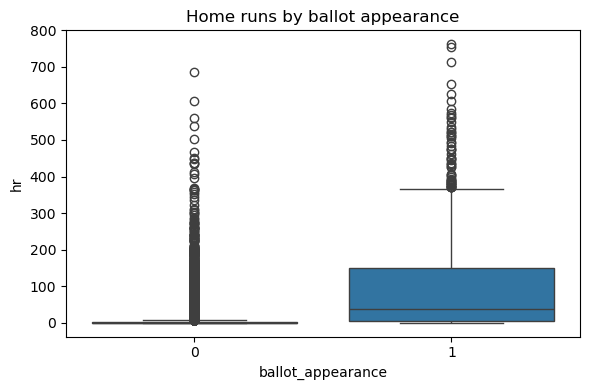

```python
plt.figure(figsize=(6,4))
sns.boxplot(data=pdf, x="ballot_appearance", y="hr")
plt.title("Home runs by ballot appearance")
plt.tight_layout()
plt.show()
```

Players with a ballot appearance hit on average far more homeruns in their career. However, it is also visible that there were players with a lot of homeruns without a ballot_appearance.

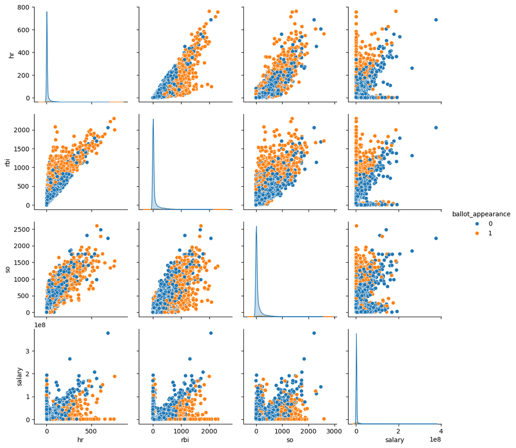

```python
pair_cols = ["ballot_appearance", "hr", "rbi", "so", "salary"]
pair_pdf = player_stats.select(pair_cols).toPandas()

sns.pairplot(pair_pdf, hue="ballot_appearance", diag_kind="kde")  # [web:191][web:185]
plt.show()
```

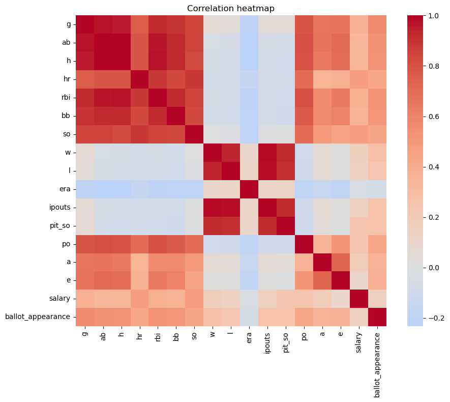

```python
corr = pdf[num_cols + ["ballot_appearance"]].corr()
plt.figure(figsize=(10,8))
sns.heatmap(corr, cmap="coolwarm", center=0, square=True)
plt.title("Correlation heatmap")
plt.tight_layout()
plt.show()
```

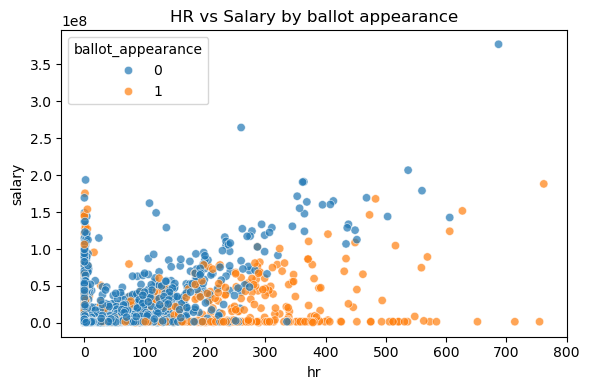

```python
plt.figure(figsize=(6,4))
sns.scatterplot(data=pdf, x="hr", y="salary", hue="ballot_appearance", alpha=0.7)
plt.title("HR vs Salary by ballot appearance")
plt.tight_layout()
plt.show()
```

This graph shows: More homeruns does not necessarily equal more salary. Pitchers for example can have a high salary without hitting a lot of homeruns.

# Save Result

```python
# player_stats is a PySpark DataFrame
pdf = player_stats.toPandas()
pdf.to_csv("player_stats.csv", index=False)
```